# Analysis of the effects of statutory working hours reduction

Dain Lee

Feb, 2024

```r
library(SmartEDA)
library(dplyr)
library(MASS)
```

```r
library(readxl)
library(HistData)
library(car)
library(lmtest)
library(wooldridge)
library(ggplot2)
library(gridExtra)
```

# 0. Data Load

```r
ds <- read.csv('C:/Users/dain/Downloads/R/oes2002_2006.csv')
summary(ds)
```

```
##       year           size            male             age
##  Min.   :2002   Min.   :8.000   Min.   :0.0000   Min.   :18.00
##  1st Qu.:2003   1st Qu.:8.000   1st Qu.:1.0000   1st Qu.:33.00
##  Median :2004   Median :9.000   Median :1.0000   Median :38.00
##  Mean   :2004   Mean   :8.511   Mean   :0.8098   Mean   :39.38
##  3rd Qu.:2006   3rd Qu.:9.000   3rd Qu.:1.0000   3rd Qu.:46.00
##  Max.   :2006   Max.   :9.000   Max.   :1.0000   Max.   :84.00
##       edu             edu1              edu2             edu3
##  Min.   : 0.00   Min.   :0.00000   Min.   :0.0000   Min.   :0.0000
##  1st Qu.:12.00   1st Qu.:0.00000   1st Qu.:0.0000   1st Qu.:0.0000
##  Median :14.00   Median :0.00000   Median :0.0000   Median :0.0000
##  Mean   :14.15   Mean   :0.05797   Mean   :0.3472   Mean   :0.1211
##  3rd Qu.:16.00   3rd Qu.:0.00000   3rd Qu.:1.0000   3rd Qu.:0.0000
##  Max.   :21.00   Max.   :1.00000   Max.   :1.0000   Max.   :1.0000
##       edu4             mar             tenure          metro
##  Min.   :0.0000   Min.   :0.0000   Min.   : 0.00   Min.   :0.0000
##  1st Qu.:0.0000   1st Qu.:1.0000   1st Qu.: 3.00   1st Qu.:0.0000
##  Median :0.0000   Median :1.0000   Median : 9.00   Median :1.0000
##  Mean   :0.4347   Mean   :0.7962   Mean   :10.04   Mean   :0.5521
##  3rd Qu.:1.0000   3rd Qu.:1.0000   3rd Qu.:15.00   3rd Qu.:1.0000
##  Max.   :1.0000   Max.   :1.0000   Max.   :50.00   Max.   :1.0000
##       oc1               oc2              oc3               oc4
##  Min.   :0.00000   Min.   :0.0000   Min.   :0.00000   Min.   :0.0000
##  1st Qu.:0.00000   1st Qu.:0.0000   1st Qu.:0.00000   1st Qu.:0.0000
##  Median :0.00000   Median :0.0000   Median :0.00000   Median :0.0000
##  Mean   :0.03028   Mean   :0.4618   Mean   :0.07275   Mean   :0.2781
##  3rd Qu.:0.00000   3rd Qu.:1.0000   3rd Qu.:0.00000   3rd Qu.:1.0000
##  Max.   :1.00000   Max.   :1.0000   Max.   :1.00000   Max.   :1.0000
##       ind1               ind2             ind3              ind4
##  Min.   :0.000000   Min.   :0.0000   Min.   :0.00000   Min.   :0.00000
##  1st Qu.:0.000000   1st Qu.:0.0000   1st Qu.:0.00000   1st Qu.:0.00000
##  Median :0.000000   Median :0.0000   Median :0.00000   Median :0.00000
##  Mean   :0.003662   Mean   :0.4369   Mean   :0.01641   Mean   :0.03561
##  3rd Qu.:0.000000   3rd Qu.:1.0000   3rd Qu.:0.00000   3rd Qu.:0.00000
##  Max.   :1.000000   Max.   :1.0000   Max.   :1.00000   Max.   :1.00000
##       ind5            ind6             ind7            ind8
##  Min.   :0.000   Min.   :0.0000   Min.   :0.000   Min.   :0.000
##  1st Qu.:0.000   1st Qu.:0.0000   1st Qu.:0.000   1st Qu.:0.000
##  Median :0.000   Median :0.0000   Median :0.000   Median :0.000
##  Mean   :0.055   Mean   :0.1184   Mean   :0.119   Mean   :0.215
##  3rd Qu.:0.000   3rd Qu.:0.0000   3rd Qu.:0.000   3rd Qu.:0.000
##  Max.   :1.000   Max.   :1.0000   Max.   :1.000   Max.   :1.000
##   non_regular         weektime        hourlywage     hourly_wage_r
##  Min.   :0.00000   Min.   : 32.00   Min.   : 0.000   Min.   : 0.000
##  1st Qu.:0.00000   1st Qu.: 40.00   1st Qu.: 1.000   1st Qu.: 1.000
##  Median :0.00000   Median : 48.00   Median : 1.000   Median : 1.000
##  Mean   :0.08632   Mean   : 49.89   Mean   : 1.296   Mean   : 1.545
##  3rd Qu.:0.00000   3rd Qu.: 55.00   3rd Qu.: 2.000   3rd Qu.: 2.000
##  Max.   :1.00000   Max.   :140.00   Max.   :40.000   Max.   :52.000
```

# 1. EDA

```r
ExpData(ds, type = 1)
```

```
##                                           Descriptions     Value
## 1                                   Sample size (nrow)     30584
## 2                              No. of variables (ncol)        28
## 3                    No. of numeric/interger variables        28
## 4                              No. of factor variables         0
## 5                                No. of text variables         0
## 6                             No. of logical variables         0
## 7                          No. of identifier variables         0
## 8                                No. of date variables         0
## 9             No. of zero variance variables (uniform)         0
## 10               %. of variables having complete cases 100% (28)
## 11   %. of variables having >0% and <50% missing cases    0% (0)
## 12 %. of variables having >=50% and <90% missing cases    0% (0)
## 13          %. of variables having >=90% missing cases    0% (0)
```

```r
ExpData(ds, type=2)
```

```
##    Index Variable_Name Variable_Type Sample_n Missing_Count Per_of_Missing
## 1      1          year       integer    30584             0              0
## 2      2          size       integer    30584             0              0
## 3      3          male       integer    30584             0              0
## 4      4           age       integer    30584             0              0
## 5      5           edu       integer    30584             0              0
## 6      6          edu1       integer    30584             0              0
## 7      7          edu2       integer    30584             0              0
## 8      8          edu3       integer    30584             0              0
## 9      9          edu4       integer    30584             0              0
## 10    10           mar       integer    30584             0              0
## 11    11        tenure       integer    30584             0              0
## 12    12         metro       integer    30584             0              0
## 13    13           oc1       integer    30584             0              0
## 14    14           oc2       integer    30584             0              0
```

[output cut: 43 more lines]

```r
ExpNumStat(ds)
```

```
##           Vname Group    TN nNeg nZero  nPos NegInf PosInf NA_Value
## 1           age   All 30584    0     0 30584      0      0        0
## 2           edu   All 30584    0    45 30539      0      0        0
## 6 hourly_wage_r   All 30584    0  1967 28617      0      0        0
## 5    hourlywage   All 30584    0  3439 27145      0      0        0
## 3        tenure   All 30584    0  1195 29389      0      0        0
## 4      weektime   All 30584    0     0 30584      0      0        0
##   Per_of_Missing     sum min max   mean median     SD    CV IQR Skewness
## 1              0 1204427  18  84 39.381     38  9.076 0.230  13    0.395
## 2              0  432806   0  21 14.151     14  2.692 0.190   4   -0.334
## 6              0   47248   0  52  1.545      1  1.028 0.666   1    8.096
## 5              0   39632   0  40  1.296      1  0.899 0.693   1    6.746
## 3              0  307175   0  50 10.044      9  7.753 0.772  12    0.764
## 4              0 1525964  32 140 49.894     48 11.823 0.237  15    2.241
##   Kurtosis
## 1   -0.176
## 2    1.199
## 6  304.547
## 5  224.725
## 3   -0.076
## 4    9.064
```

```r
ExpNumStat(ds, by='GA', gp='size')
```

```
##            Vname    Group    TN nNeg nZero  nPos NegInf PosInf NA_Value
## 1            age size:All 30584    0     0 30584      0      0        0
## 7            age   size:8 14969    0     0 14969      0      0        0
## 13           age   size:9 15615    0     0 15615      0      0        0
## 2            edu size:All 30584    0    45 30539      0      0        0
## 8            edu   size:8 14969    0    29 14940      0      0        0
## 14           edu   size:9 15615    0    16 15599      0      0        0
## 6  hourly_wage_r size:All 30584    0  1967 28617      0      0        0
## 12 hourly_wage_r   size:8 14969    0  1318 13651      0      0        0
## 18 hourly_wage_r   size:9 15615    0   649 14966      0      0        0
## 5     hourlywage size:All 30584    0  3439 27145      0      0        0
## 11    hourlywage   size:8 14969    0  2188 12781      0      0        0
## 17    hourlywage   size:9 15615    0  1251 14364      0      0        0
## 3         tenure size:All 30584    0  1195 29389      0      0        0
## 9         tenure   size:8 14969    0   718 14251      0      0        0
```

[output cut: 42 more lines]

```
## $`0`
```

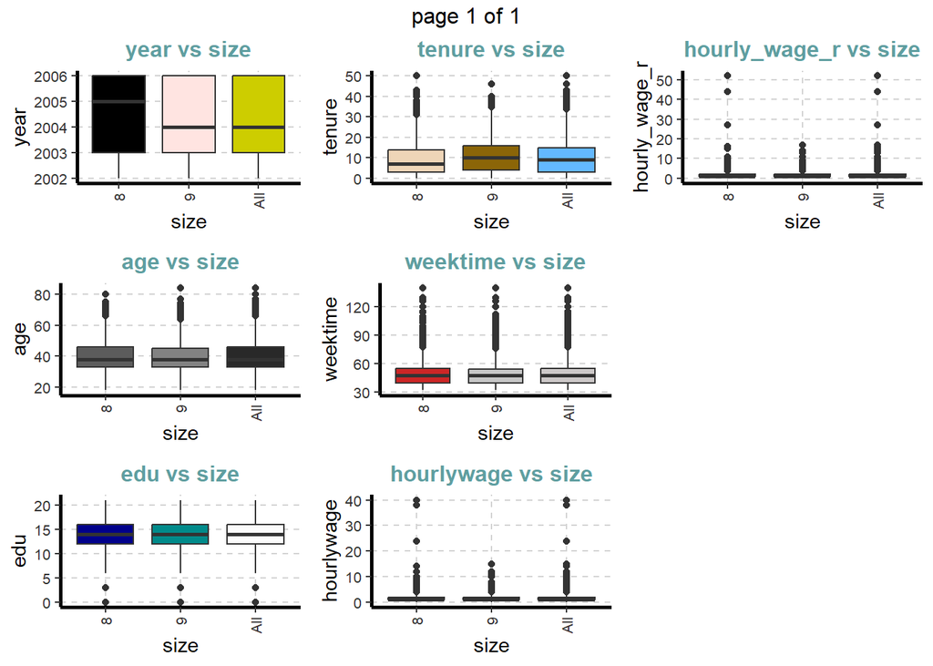

```r
plot <- ds |> ExpNumViz(Page=c(3,3), target = 'size')

plot
```

다른 변수는 거의 동일하게 분포한 반면, size=8에서 임금, 실질임금의 이상치가 더 많이 나타납니다.

```
## $`0`
```

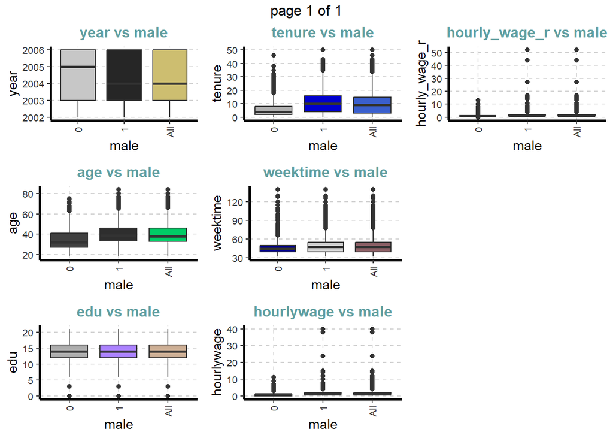

```r
plot <- ds |> ExpNumViz(Page=c(3,3), target = 'male')

plot
```

남성 근로자의 나이가 평균적으로 많고, 정규직 근속연수가 조금 더 깁니다. 임금, 실질임금의 꼬리가 깁니다(이상치가 있습니다).

```
## $`0`
```

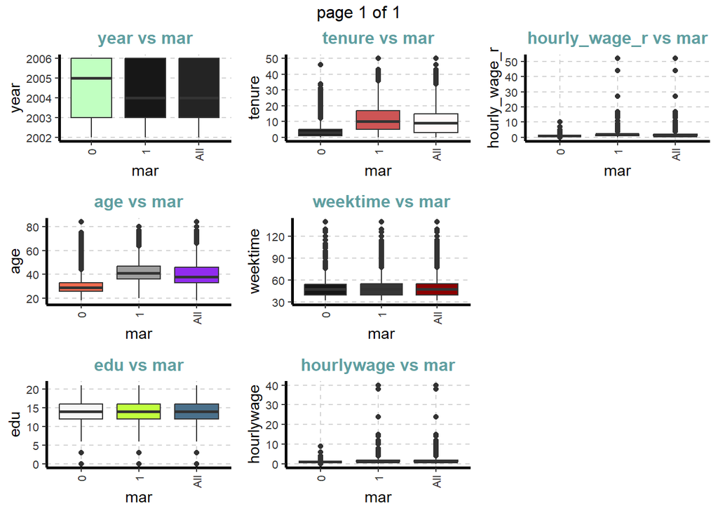

```r
plot <- ds |> ExpNumViz(Page=c(3,3), target = 'mar')

plot
```

기혼 근로자의 나이와 근속연수가 평균적으로 더 많(길)고, 임금, 실질임금의 꼬리가 깁니다.

```
## $`0`
```

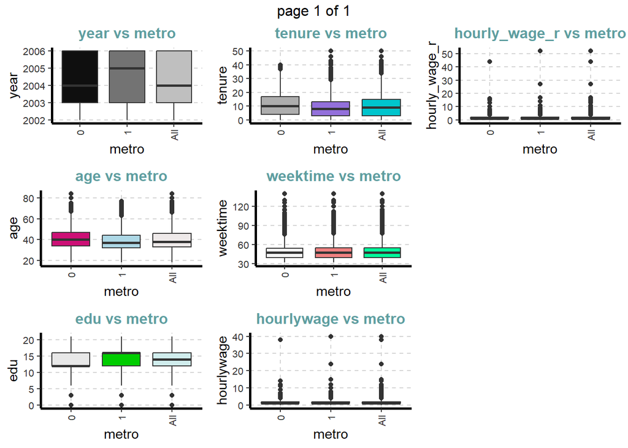

```r
plot <- ds |> ExpNumViz(Page=c(3,3), target = 'metro')

plot
```

```
## $`0`
```

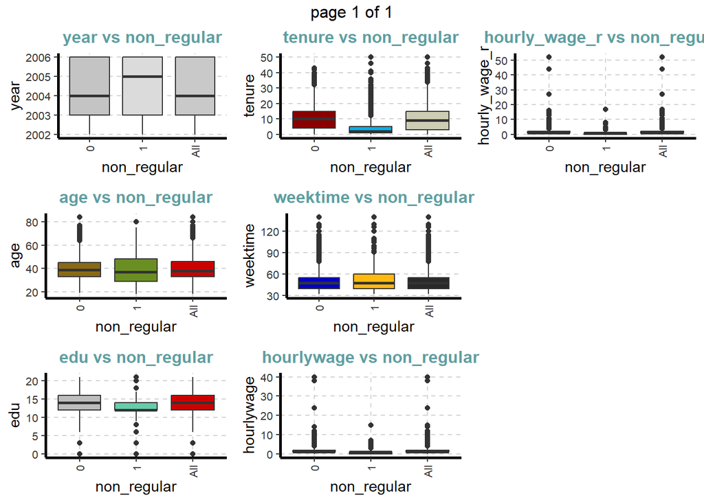

```r
plot <- ds |> ExpNumViz(Page=c(3,3), target = 'non_regular')

plot
```

```r
ExpCTable(ds)
```

```
##       Variable Valid Frequency Percent CumPercent
## 1         year  2002      4831   15.80      15.80
## 2         year  2003      5193   16.98      32.78
## 3         year  2004      5587   18.27      51.05
## 4         year  2005      5446   17.81      68.86
## 5         year  2006      9527   31.15     100.01
## 6         year TOTAL     30584      NA         NA
## 7         size     8     14969   48.94      48.94
## 8         size     9     15615   51.06     100.00
## 9         size TOTAL     30584      NA         NA
## 10        male     0      5818   19.02      19.02
## 11        male     1     24766   80.98     100.00
## 12        male TOTAL     30584      NA         NA
## 13        edu1     0     28811   94.20      94.20
## 14        edu1     1      1773    5.80     100.00
```

[output cut: 55 more lines]

```
## $`0`
```

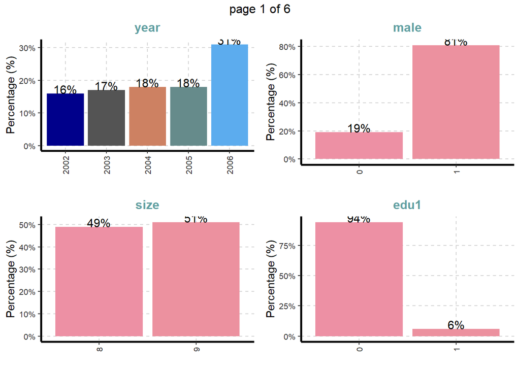

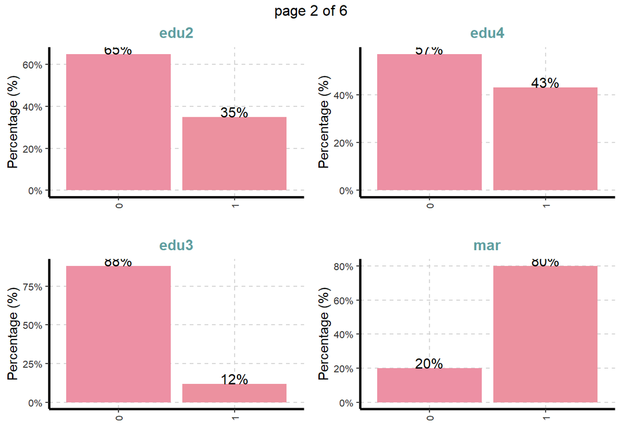

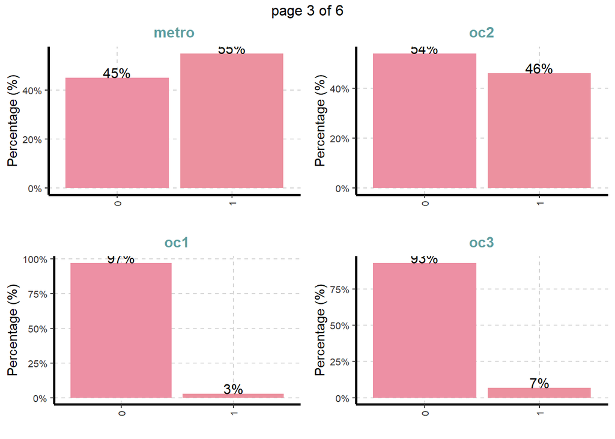

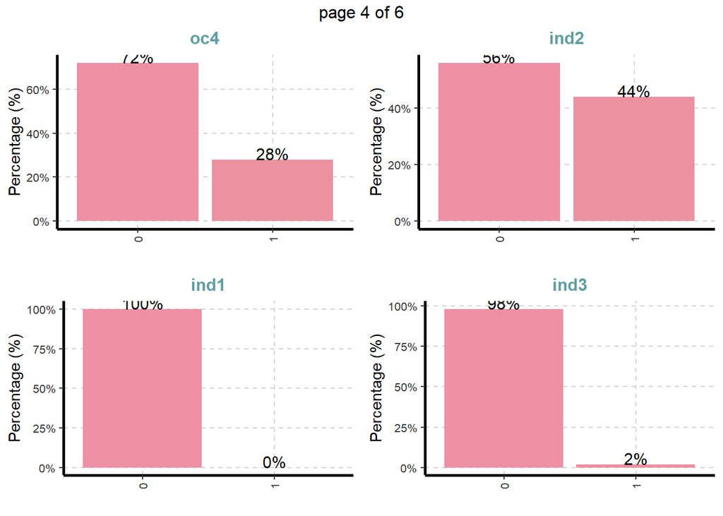

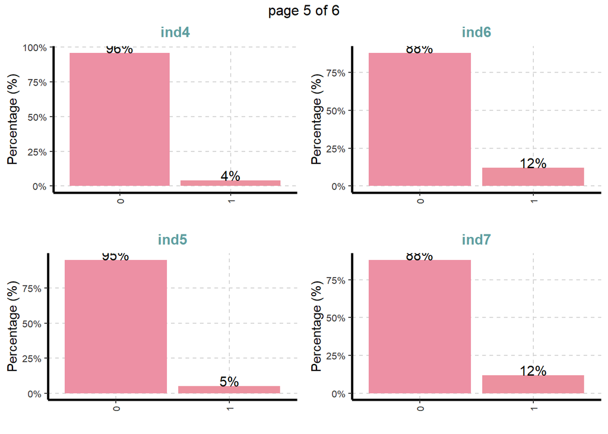

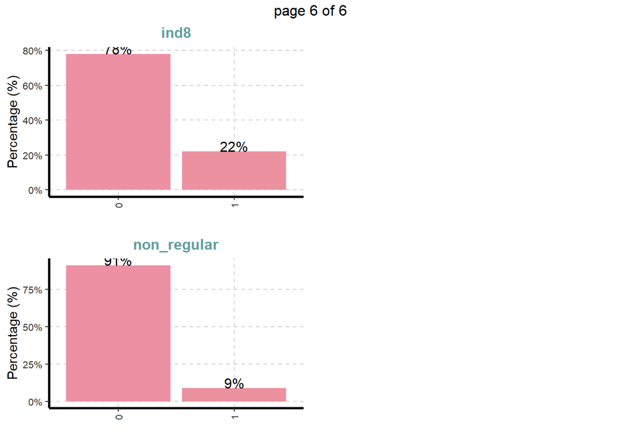

```r
plot2 <- ExpCatViz(ds, Page=c(2,2))
plot2
```

# 2. Estimation of Systematic Differnce between Size=8 and 9

```r
ds$Q <- as.numeric(ds$size==9)

r1 = lm(male~Q, data=ds)
r2 = lm(edu~Q, data=ds)
r3 = lm(mar~Q, data=ds)
r4 = lm(tenure~Q, data=ds)
r5 = lm(metro~Q, data=ds)
r6 = lm(non_regular~Q, data=ds)
r7 = lm(weektime~Q, data=ds)
r8 = lm(hourlywage~Q, data=ds)
r9 = lm(hourly_wage_r~Q, data=ds)

summary(r1)
```

```
##
## Call:
## lm(formula = male ~ Q, data = ds)
##
## Residuals:
##     Min      1Q  Median      3Q     Max
## -0.8394  0.1606  0.1606  0.2211  0.2211
##
## Coefficients:
##             Estimate Std. Error t value Pr(>|t|)
## (Intercept) 0.778876   0.003198  243.51   <2e-16 ***
## Q           0.060509   0.004476   13.52   <2e-16 ***
## ---
## Signif. codes:  0 '***' 0.001 '**' 0.01 '*' 0.05 '.' 0.1 ' ' 1
##
## Residual standard error: 0.3913 on 30582 degrees of freedom
## Multiple R-squared:  0.005939,   Adjusted R-squared:  0.005907
## F-statistic: 182.7 on 1 and 30582 DF,  p-value: < 2.2e-16
```

```r
summary(r2)
```

```
##
## Call:
## lm(formula = edu ~ Q, data = ds)
##
## Residuals:
##      Min       1Q   Median       3Q      Max
## -14.2100  -2.0903  -0.0903   1.9097   6.9097
##
## Coefficients:
##             Estimate Std. Error t value Pr(>|t|)
## (Intercept) 14.09025    0.02200 640.433  < 2e-16 ***
## Q            0.11974    0.03079   3.889 0.000101 ***
## ---
## Signif. codes:  0 '***' 0.001 '**' 0.01 '*' 0.05 '.' 0.1 ' ' 1
##
## Residual standard error: 2.692 on 30582 degrees of freedom
## Multiple R-squared:  0.0004942,  Adjusted R-squared:  0.0004616
## F-statistic: 15.12 on 1 and 30582 DF,  p-value: 0.000101
```

```r
summary(r3)
```

```
##
## Call:
## lm(formula = mar ~ Q, data = ds)
##
## Residuals:
##     Min      1Q  Median      3Q     Max
## -0.8096  0.1904  0.1904  0.2178  0.2178
##
## Coefficients:
##             Estimate Std. Error t value Pr(>|t|)
## (Intercept) 0.782217   0.003291 237.710  < 2e-16 ***
## Q           0.027390   0.004605   5.947 2.75e-09 ***
## ---
## Signif. codes:  0 '***' 0.001 '**' 0.01 '*' 0.05 '.' 0.1 ' ' 1
##
## Residual standard error: 0.4026 on 30582 degrees of freedom
## Multiple R-squared:  0.001155,   Adjusted R-squared:  0.001123
## F-statistic: 35.37 on 1 and 30582 DF,  p-value: 2.753e-09
```

```r
summary(r4)
```

```
##
## Call:
## lm(formula = tenure ~ Q, data = ds)
##
## Residuals:
##     Min      1Q  Median      3Q     Max
## -10.895  -6.156  -1.156   5.105  40.844
##
## Coefficients:
##             Estimate Std. Error t value Pr(>|t|)
## (Intercept)  9.15552    0.06297  145.40   <2e-16 ***
## Q            1.73952    0.08813   19.74   <2e-16 ***
## ---
## Signif. codes:  0 '***' 0.001 '**' 0.01 '*' 0.05 '.' 0.1 ' ' 1
##
## Residual standard error: 7.704 on 30582 degrees of freedom
## Multiple R-squared:  0.01258,    Adjusted R-squared:  0.01255
## F-statistic: 389.6 on 1 and 30582 DF,  p-value: < 2.2e-16
```

```r
summary(r5)
```

```
##
## Call:
## lm(formula = metro ~ Q, data = ds)
##
## Residuals:
##     Min      1Q  Median      3Q     Max
## -0.5662 -0.5374  0.4338  0.4626  0.4626
##
## Coefficients:
##             Estimate Std. Error t value Pr(>|t|)
## (Intercept) 0.537377   0.004063 132.264  < 2e-16 ***
## Q           0.028809   0.005686   5.067 4.07e-07 ***
## ---
## Signif. codes:  0 '***' 0.001 '**' 0.01 '*' 0.05 '.' 0.1 ' ' 1
##
## Residual standard error: 0.4971 on 30582 degrees of freedom
## Multiple R-squared:  0.0008387,  Adjusted R-squared:  0.000806
## F-statistic: 25.67 on 1 and 30582 DF,  p-value: 4.073e-07
```

```r
summary(r6)
```

```
##
## Call:
## lm(formula = non_regular ~ Q, data = ds)
##
## Residuals:
##      Min       1Q   Median       3Q      Max
## -0.10308 -0.10308 -0.07025 -0.07025  0.92975
##
## Coefficients:
##              Estimate Std. Error t value Pr(>|t|)
## (Intercept)  0.103080   0.002292   44.98   <2e-16 ***
## Q           -0.032827   0.003207  -10.24   <2e-16 ***
## ---
## Signif. codes:  0 '***' 0.001 '**' 0.01 '*' 0.05 '.' 0.1 ' ' 1
##
## Residual standard error: 0.2804 on 30582 degrees of freedom
## Multiple R-squared:  0.003414,   Adjusted R-squared:  0.003382
## F-statistic: 104.8 on 1 and 30582 DF,  p-value: < 2.2e-16
```

```r
summary(r7)
```

```
##
## Call:
## lm(formula = weektime ~ Q, data = ds)
##
## Residuals:
##     Min      1Q  Median      3Q     Max
## -18.288  -9.516  -2.288   4.712  90.484
##
## Coefficients:
##             Estimate Std. Error t value Pr(>|t|)
## (Intercept) 50.28826    0.09658  520.68  < 2e-16 ***
## Q           -0.77184    0.13517   -5.71 1.14e-08 ***
## ---
## Signif. codes:  0 '***' 0.001 '**' 0.01 '*' 0.05 '.' 0.1 ' ' 1
##
## Residual standard error: 11.82 on 30582 degrees of freedom
## Multiple R-squared:  0.001065,   Adjusted R-squared:  0.001032
## F-statistic: 32.61 on 1 and 30582 DF,  p-value: 1.139e-08
```

```r
summary(r8)
```

```
##
## Call:
## lm(formula = hourlywage ~ Q, data = ds)
##
## Residuals:
##    Min     1Q Median     3Q    Max
## -1.397 -0.397 -0.190  0.603 38.810
##
## Coefficients:
##             Estimate Std. Error t value Pr(>|t|)
## (Intercept) 1.190059   0.007296  163.12   <2e-16 ***
## Q           0.207187   0.010210   20.29   <2e-16 ***
## ---
## Signif. codes:  0 '***' 0.001 '**' 0.01 '*' 0.05 '.' 0.1 ' ' 1
##
## Residual standard error: 0.8926 on 30582 degrees of freedom
## Multiple R-squared:  0.01329,    Adjusted R-squared:  0.01325
## F-statistic: 411.8 on 1 and 30582 DF,  p-value: < 2.2e-16
```

```r
summary(r9)
```

```
##
## Call:
## lm(formula = hourly_wage_r ~ Q, data = ds)
##
## Residuals:
##    Min     1Q Median     3Q    Max
## -1.661 -0.661 -0.423  0.577 50.577
##
## Coefficients:
##             Estimate Std. Error t value Pr(>|t|)
## (Intercept) 1.423208   0.008349  170.47   <2e-16 ***
## Q           0.238271   0.011684   20.39   <2e-16 ***
## ---
## Signif. codes:  0 '***' 0.001 '**' 0.01 '*' 0.05 '.' 0.1 ' ' 1
##
## Residual standard error: 1.021 on 30582 degrees of freedom
## Multiple R-squared:  0.01342,    Adjusted R-squared:  0.01338
## F-statistic: 415.9 on 1 and 30582 DF,  p-value: < 2.2e-16
```

직책, 산업군을 제외한 모든 변수가 기업의 규모에 따라 다르다. size=9가 주당 근무시간은 더 적고, 주당 임금, 실질 임금은 평균적으로 더 높다.

# Differnce in Differnce

## 3. Introduction to DD

DD(이중차분법)의 기본 가정은 정책 변화 전의 처리 그룹(treatment)과 통제 그룹(control)의 추세(trend)가 일정해야 한다는 것입니다. 예를 들어 t=-2 시기의 두 그룹의 임금 격차가 t=-1 시기나 t=0 시기에도 비슷하게 유지되어야 t=1 시기의 임금 변화가 처리 효과로서 유의미함을 의미합니다.

```r
ds$y1 = ds$weektime
ds$y2 = ds$hourly_wage_r
ds$y3 = ds$y1*ds$y2

ds$t02 = as.numeric(ds$year==2002)
ds$t03 = as.numeric(ds$year==2003)
ds$t04 = as.numeric(ds$year==2004)
ds$t05 = as.numeric(ds$year==2005)
ds$t06 = as.numeric(ds$year==2006)
```

```r
minfo_y1 = aggregate(ds$y1, list(ds$year,ds$Q == 1), mean)
names(minfo_y1) = c("YR","Treatment","y1")

minfo_y1$Group[1:5] = "y1, Size==8"
minfo_y1$Group[6:10] = "y1, Size==9"
minfo_y1
```

```
##      YR Treatment       y1       Group
## 1  2002     FALSE 53.25639 y1, Size==8
## 2  2003     FALSE 52.87574 y1, Size==8
## 3  2004     FALSE 50.83986 y1, Size==8
## 4  2005     FALSE 48.43650 y1, Size==8
## 5  2006     FALSE 48.16488 y1, Size==8
## 6  2002      TRUE 52.98295 y1, Size==9
## 7  2003      TRUE 52.66017 y1, Size==9
## 8  2004      TRUE 48.46468 y1, Size==9
## 9  2005      TRUE 47.93169 y1, Size==9
## 10 2006      TRUE 47.59390 y1, Size==9
```

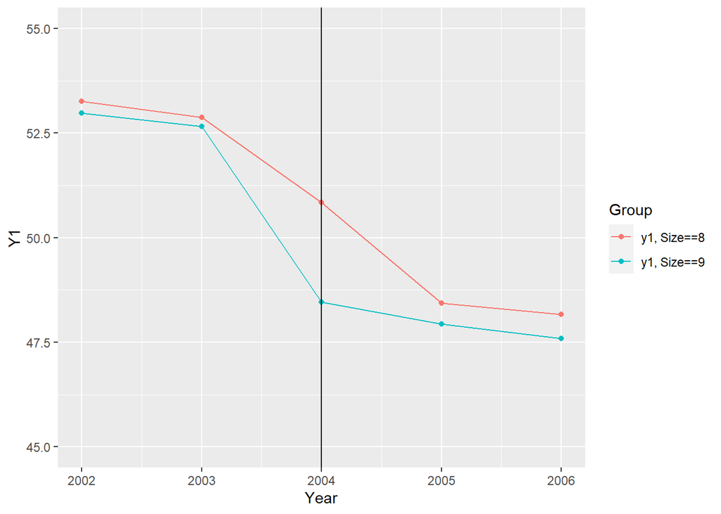

```r
qplot(YR, y1, data=minfo_y1, geom=c("point","line"), colour=Group,
      xlab="Year", ylab="Y1",
      ylim=c(45, 55)) + geom_vline(xintercept = 2004)
```

```r
minfo_y2 = aggregate(ds$y2, list(ds$year,ds$Q == 1), mean)
names(minfo_y2) = c("YR","Treatment","y2")

minfo_y2$Group[1:5] = "y2, Size==8"
minfo_y2$Group[6:10] = "y2, Size==9"
minfo_y2
```

```
##      YR Treatment       y2       Group
## 1  2002     FALSE 1.257626 y2, Size==8
## 2  2003     FALSE 1.266719 y2, Size==8
## 3  2004     FALSE 1.281139 y2, Size==8
## 4  2005     FALSE 1.482746 y2, Size==8
## 5  2006     FALSE 1.634731 y2, Size==8
## 6  2002      TRUE 1.360499 y2, Size==9
## 7  2003      TRUE 1.418980 y2, Size==9
## 8  2004      TRUE 1.651079 y2, Size==9
## 9  2005      TRUE 1.710436 y2, Size==9
## 10 2006      TRUE 1.923933 y2, Size==9
```

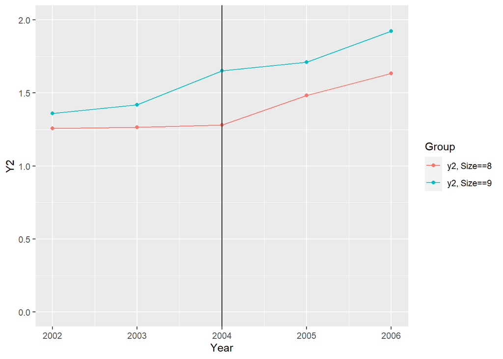

```r
qplot(YR, y2, data=minfo_y2, geom=c("point","line"), colour=Group,
      xlab="Year", ylab="Y2",
      ylim=c(0, 2)) + geom_vline(xintercept = 2004)
```

```r
minfo_y3 = aggregate(ds$y3, list(ds$year,ds$Q == 1), mean)
names(minfo_y3) = c("YR","Treatment","y3")

minfo_y3$Group[1:5] = "y3, Size==8"
minfo_y3$Group[6:10] = "y3, Size==9"
minfo_y3
```

```
##      YR Treatment       y3       Group
## 1  2002     FALSE 63.42086 y3, Size==8
## 2  2003     FALSE 63.80253 y3, Size==8
## 3  2004     FALSE 61.70344 y3, Size==8
## 4  2005     FALSE 68.08467 y3, Size==8
## 5  2006     FALSE 74.92622 y3, Size==8
## 6  2002      TRUE 69.47069 y3, Size==9
## 7  2003      TRUE 71.69130 y3, Size==9
## 8  2004      TRUE 76.29922 y3, Size==9
## 9  2005      TRUE 78.39013 y3, Size==9
## 10 2006      TRUE 87.77716 y3, Size==9
```

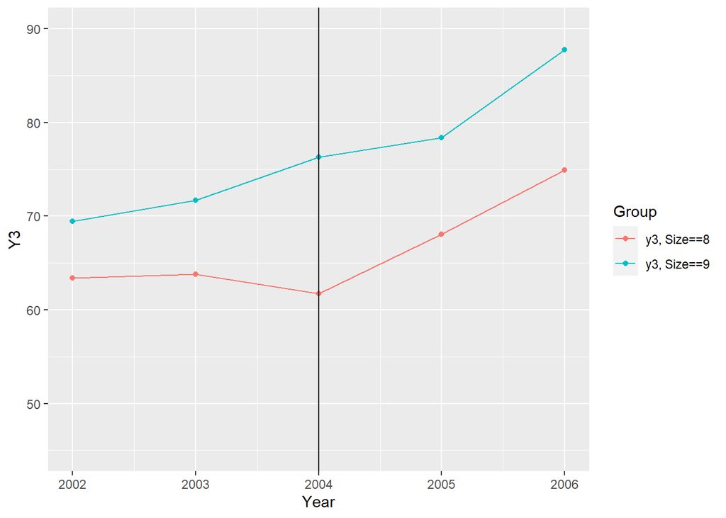

```r
qplot(YR, y3, data=minfo_y3, geom=c("point","line"), colour=Group,
      xlab="Year", ylab="Y3",
      ylim=c(45, 90)) + geom_vline(xintercept = 2004)
```

설명변수 y1은 정책 시행 전인 2002, 2003년에는 데이터 격차가 비슷하게 유지되다 2004년에 급격히 변화합니다. 한편, y2와 y3는 2004년에 비해서는 2002, 2003년의 격차가 비슷하지만 DD를 사용해 유의미한 변화를 측정하기 위해서는 추가적인 변수 컨트롤이 필요합니다.

## 4. Control for covariates

전체 변수에 대해 통제하여 두 그룹의 조건이 완전히 동일한 상태에서 정책 효과가 유의하게 발생하는지 관찰합니다. 2003년 데이터와 2004년 데이터만 활용하여 두 해 사이의 차이를 보입니다. 설명변수에 대해 비선형적인 영향을 줄 것으로 예상되는 age 변수에 대해서는 age^2 값을 동시에 활용하겠습니다.

```r
ds$age2 = ds$age^2
ds$Q4= as.numeric((ds$t03+ds$t04)==1)

reg1 = lm(y1 ~Q*t04+male+age+age2+edu2+edu3+edu4+mar+tenure+metro+oc2+oc3+oc4+ind2+ind3+ind4+ind5+ind6+ind7+ind8+non_regular, data = ds, Q4==1)
summary(reg1)
```

```
##
## Call:
## lm(formula = y1 ~ Q * t04 + male + age + age2 + edu2 + edu3 +
##     edu4 + mar + tenure + metro + oc2 + oc3 + oc4 + ind2 + ind3 +
##     ind4 + ind5 + ind6 + ind7 + ind8 + non_regular, data = ds,
##     subset = Q4 == 1)
##
## Residuals:
##     Min      1Q  Median      3Q     Max
## -24.557  -7.507  -2.823   4.979  94.666
##
## Coefficients:
##              Estimate Std. Error t value Pr(>|t|)
## (Intercept) 49.400704   2.679089  18.439  < 2e-16 ***
## Q            0.041146   0.316493   0.130 0.896564
## t04         -2.037179   0.316944  -6.428 1.35e-10 ***
## male         3.452817   0.322326  10.712  < 2e-16 ***
## age         -0.050277   0.103817  -0.484 0.628196
## age2         0.000859   0.001198   0.717 0.473417
## edu2        -1.480779   0.519757  -2.849 0.004394 **
## edu3        -2.450741   0.619344  -3.957 7.64e-05 ***
## edu4        -2.451606   0.583753  -4.200 2.69e-05 ***
## mar         -0.424490   0.358428  -1.184 0.236317
## tenure      -0.152795   0.019584  -7.802 6.66e-15 ***
## metro        1.179480   0.239517   4.924 8.59e-07 ***
## oc2         -1.723414   0.610171  -2.824 0.004745 **
## oc3          1.349856   0.724822   1.862 0.062584 .
## oc4          0.470659   0.657854   0.715 0.474349
## ind2         4.730858   1.648951   2.869 0.004126 **
## ind3         0.088578   1.841035   0.048 0.961627
## ind4         6.362570   1.742965   3.650 0.000263 ***
## ind5         5.370611   1.710849   3.139 0.001699 **
## ind6         8.075656   1.677528   4.814 1.50e-06 ***
## ind7         3.028349   1.682754   1.800 0.071946 .
## ind8         3.972149   1.664869   2.386 0.017056 *
## non_regular  0.597573   0.444884   1.343 0.179233
## Q:t04       -2.022805   0.435698  -4.643 3.48e-06 ***
## ---
## Signif. codes:  0 '***' 0.001 '**' 0.01 '*' 0.05 '.' 0.1 ' ' 1
##
## Residual standard error: 11.24 on 10756 degrees of freedom
## Multiple R-squared:  0.08576,    Adjusted R-squared:  0.0838
## F-statistic: 43.87 on 23 and 10756 DF,  p-value: < 2.2e-16
```

```r
reg2 = lm(y2 ~Q*t04+male+age+age2+edu2+edu3+edu4+mar+tenure+metro+oc2+oc3+oc4+ind2+ind3+ind4+ind5+ind6+ind7+ind8+non_regular, data = ds, Q4==1)
summary(reg2)
```

```
##
## Call:
## lm(formula = y2 ~ Q * t04 + male + age + age2 + edu2 + edu3 +
##     edu4 + mar + tenure + metro + oc2 + oc3 + oc4 + ind2 + ind3 +
##     ind4 + ind5 + ind6 + ind7 + ind8 + non_regular, data = ds,
##     subset = Q4 == 1)
##
## Residuals:
##     Min      1Q  Median      3Q     Max
## -2.4429 -0.4590 -0.0565  0.3435 13.1742
##
## Coefficients:
##               Estimate Std. Error t value Pr(>|t|)
## (Intercept) -1.267e-02  1.643e-01  -0.077 0.938534
## Q            8.299e-02  1.941e-02   4.275 1.93e-05 ***
## t04          5.858e-02  1.944e-02   3.013 0.002590 **
## male         2.063e-01  1.977e-02  10.434  < 2e-16 ***
## age          3.952e-02  6.368e-03   6.206 5.63e-10 ***
## age2        -3.241e-04  7.349e-05  -4.410 1.05e-05 ***
## edu2         3.761e-01  3.188e-02  11.796  < 2e-16 ***
## edu3         5.280e-01  3.799e-02  13.899  < 2e-16 ***
## edu4         8.068e-01  3.581e-02  22.531  < 2e-16 ***
## mar          8.551e-02  2.199e-02   3.889 0.000101 ***
## tenure       2.091e-02  1.201e-03  17.403  < 2e-16 ***
## metro        4.909e-02  1.469e-02   3.342 0.000836 ***
## oc2         -6.215e-01  3.743e-02 -16.604  < 2e-16 ***
## oc3         -7.910e-01  4.446e-02 -17.791  < 2e-16 ***
## oc4         -7.846e-01  4.035e-02 -19.444  < 2e-16 ***
## ind2        -5.727e-02  1.011e-01  -0.566 0.571249
## ind3         2.575e-01  1.129e-01   2.280 0.022643 *
## ind4        -5.107e-02  1.069e-01  -0.478 0.632922
## ind5        -3.029e-02  1.049e-01  -0.289 0.772851
## ind6        -1.188e-01  1.029e-01  -1.154 0.248334
## ind7         1.606e-01  1.032e-01   1.556 0.119695
## ind8        -8.428e-02  1.021e-01  -0.825 0.409226
## non_regular -3.193e-01  2.729e-02 -11.702  < 2e-16 ***
## Q:t04        1.207e-01  2.673e-02   4.516 6.38e-06 ***
## ---
## Signif. codes:  0 '***' 0.001 '**' 0.01 '*' 0.05 '.' 0.1 ' ' 1
##
## Residual standard error: 0.6893 on 10756 degrees of freedom
## Multiple R-squared:  0.3711, Adjusted R-squared:  0.3697
## F-statistic: 275.9 on 23 and 10756 DF,  p-value: < 2.2e-16
```

```r
reg3 = lm(y3 ~Q*t04+male+age+age2+edu2+edu3+edu4+mar+tenure+metro+oc2+oc3+oc4+ind2+ind3+ind4+ind5+ind6+ind7+ind8+non_regular, data = ds, Q4==1)
summary(reg3)
```

```
##
## Call:
## lm(formula = y3 ~ Q * t04 + male + age + age2 + edu2 + edu3 +
##     edu4 + mar + tenure + metro + oc2 + oc3 + oc4 + ind2 + ind3 +
##     ind4 + ind5 + ind6 + ind7 + ind8 + non_regular, data = ds,
##     subset = Q4 == 1)
##
## Residuals:
##     Min      1Q  Median      3Q     Max
## -116.09  -19.84   -1.99   16.61  738.96
##
## Coefficients:
##               Estimate Std. Error t value Pr(>|t|)
## (Intercept)  -4.583817   7.336264  -0.625   0.5321
## Q             4.595788   0.866667   5.303 1.16e-07 ***
## t04           0.040478   0.867900   0.047   0.9628
## male         13.604653   0.882639  15.414  < 2e-16 ***
## age           2.153328   0.284287   7.574 3.90e-14 ***
## age2         -0.019532   0.003281  -5.953 2.71e-09 ***
## edu2         16.111533   1.423274  11.320  < 2e-16 ***
## edu3         22.124121   1.695976  13.045  < 2e-16 ***
## edu4         35.205965   1.598517  22.024  < 2e-16 ***
## mar           3.921422   0.981499   3.995 6.50e-05 ***
## tenure        0.891547   0.053628  16.625  < 2e-16 ***
## metro         3.738073   0.655879   5.699 1.23e-08 ***
## oc2         -31.623814   1.670858 -18.927  < 2e-16 ***
## oc3         -37.103121   1.984812 -18.694  < 2e-16 ***
## oc4         -37.785751   1.801429 -20.975  < 2e-16 ***
## ind2          1.896804   4.515394   0.420   0.6744
## ind3          9.309713   5.041384   1.847   0.0648 .
## ind4          5.202688   4.772837   1.090   0.2757
## ind5          3.250583   4.684890   0.694   0.4878
## ind6          0.886289   4.593647   0.193   0.8470
## ind7          9.563263   4.607958   2.075   0.0380 *
## ind8         -0.305205   4.558983  -0.067   0.9466
## non_regular -15.098806   1.218246 -12.394  < 2e-16 ***
## Q:t04         2.245194   1.193090   1.882   0.0599 .
## ---
## Signif. codes:  0 '***' 0.001 '**' 0.01 '*' 0.05 '.' 0.1 ' ' 1
##
## Residual standard error: 30.77 on 10756 degrees of freedom
## Multiple R-squared:  0.3773, Adjusted R-squared:  0.3759
## F-statistic: 283.3 on 23 and 10756 DF,  p-value: < 2.2e-16
```

다만, 위 회귀식은 나이 변수를 제외한 모든 변수가 설명변수에 선형적인 영향을 미칠 것을 가정하여 계산된 식입니다. 그러나 모든 공변량이 선형적인 영향을 주는 것은 아닙니다. 다음 단계에서 직관에 따라 공변량에 추가적인 처치를 하고 다시 관찰해 보겠습니다.

## 5. Additional Control for covariates

```r
ds$tenure2 = ds$tenure^2
ds$fem = as.numeric(ds$male==0)
ds$marfem = ds$mar * ds$fem

reg4 = lm(y1 ~Q*t04+male+age+age2+edu2+edu3+edu4+mar+tenure+tenure2+metro+oc2+oc3+oc4+ind2+ind3+ind4+ind5+ind6+ind7+ind8+non_regular, data = ds, Q4==1)
summary(reg4)
```

```
##
## Call:
## lm(formula = y1 ~ Q * t04 + male + age + age2 + edu2 + edu3 +
##     edu4 + mar + tenure + tenure2 + metro + oc2 + oc3 + oc4 +
##     ind2 + ind3 + ind4 + ind5 + ind6 + ind7 + ind8 + non_regular,
##     data = ds, subset = Q4 == 1)
##
## Residuals:
##     Min      1Q  Median      3Q     Max
## -24.500  -7.522  -2.829   4.981  94.656
##
## Coefficients:
##               Estimate Std. Error t value Pr(>|t|)
## (Intercept) 49.0164045  2.7269662  17.975  < 2e-16 ***
## Q            0.0493502  0.3166857   0.156 0.876167
## t04         -2.0396933  0.3169673  -6.435 1.29e-10 ***
## male         3.4504226  0.3223481  10.704  < 2e-16 ***
## age         -0.0243265  0.1093496  -0.222 0.823955
## age2         0.0005356  0.0012723   0.421 0.673806
## edu2        -1.5015346  0.5204926  -2.885 0.003924 **
## edu3        -2.4634362  0.6195841  -3.976 7.06e-05 ***
## edu4        -2.4677780  0.5841571  -4.225 2.41e-05 ***
## mar         -0.3976293  0.3601927  -1.104 0.269646
## tenure      -0.1895496  0.0524262  -3.616 0.000301 ***
## tenure2      0.0014156  0.0018730   0.756 0.449787
## metro        1.1822837  0.2395502   4.935 8.12e-07 ***
## oc2         -1.7025565  0.6108070  -2.787 0.005323 **
## oc3          1.3611365  0.7249905   1.877 0.060483 .
## oc4          0.4983267  0.6588846   0.756 0.449475
## ind2         4.7431161  1.6490641   2.876 0.004032 **
## ind3         0.0822287  1.8410906   0.045 0.964377
## ind4         6.3681127  1.7430156   3.654 0.000260 ***
## ind5         5.3769813  1.7109037   3.143 0.001678 **
## ind6         8.0748011  1.6775619   4.813 1.50e-06 ***
## ind7         3.0329247  1.6827986   1.802 0.071525 .
## ind8         3.9752305  1.6649075   2.388 0.016973 *
## non_regular  0.5547842  0.4484807   1.237 0.216103
## Q:t04       -2.0268292  0.4357389  -4.651 3.33e-06 ***
## ---
## Signif. codes:  0 '***' 0.001 '**' 0.01 '*' 0.05 '.' 0.1 ' ' 1
##
## Residual standard error: 11.24 on 10755 degrees of freedom
## Multiple R-squared:  0.08581,    Adjusted R-squared:  0.08377
## F-statistic: 42.06 on 24 and 10755 DF,  p-value: < 2.2e-16
```

```r
reg5 = lm(y2 ~Q*t04+male+age+age2+edu2+edu3+edu4+mar+tenure+tenure2+metro+oc2+oc3+oc4+ind2+ind3+ind4+ind5+ind6+ind7+ind8+non_regular, data = ds, Q4==1)
summary(reg5)
```

```
##
## Call:
## lm(formula = y2 ~ Q * t04 + male + age + age2 + edu2 + edu3 +
##     edu4 + mar + tenure + tenure2 + metro + oc2 + oc3 + oc4 +
##     ind2 + ind3 + ind4 + ind5 + ind6 + ind7 + ind8 + non_regular,
##     data = ds, subset = Q4 == 1)
##
## Residuals:
##     Min      1Q  Median      3Q     Max
## -2.4887 -0.4581 -0.0604  0.3469 13.1573
##
## Coefficients:
##               Estimate Std. Error t value Pr(>|t|)
## (Intercept)  8.758e-02  1.672e-01   0.524 0.600432
## Q            8.085e-02  1.942e-02   4.164 3.16e-05 ***
## t04          5.924e-02  1.943e-02   3.048 0.002308 **
## male         2.069e-01  1.976e-02  10.469  < 2e-16 ***
## age          3.275e-02  6.705e-03   4.885 1.05e-06 ***
## age2        -2.397e-04  7.801e-05  -3.073 0.002125 **
## edu2         3.815e-01  3.191e-02  11.955  < 2e-16 ***
## edu3         5.314e-01  3.799e-02  13.987  < 2e-16 ***
## edu4         8.110e-01  3.582e-02  22.644  < 2e-16 ***
## mar          7.850e-02  2.208e-02   3.555 0.000380 ***
## tenure       3.049e-02  3.214e-03   9.487  < 2e-16 ***
## tenure2     -3.693e-04  1.148e-04  -3.216 0.001305 **
## metro        4.836e-02  1.469e-02   3.293 0.000995 ***
## oc2         -6.269e-01  3.745e-02 -16.740  < 2e-16 ***
## oc3         -7.940e-01  4.445e-02 -17.861  < 2e-16 ***
## oc4         -7.918e-01  4.040e-02 -19.601  < 2e-16 ***
## ind2        -6.047e-02  1.011e-01  -0.598 0.549803
## ind3         2.591e-01  1.129e-01   2.295 0.021731 *
## ind4        -5.251e-02  1.069e-01  -0.491 0.623179
## ind5        -3.195e-02  1.049e-01  -0.305 0.760664
## ind6        -1.186e-01  1.029e-01  -1.153 0.249018
## ind7         1.594e-01  1.032e-01   1.545 0.122309
## ind8        -8.509e-02  1.021e-01  -0.834 0.404570
## non_regular -3.082e-01  2.750e-02 -11.207  < 2e-16 ***
## Q:t04        1.217e-01  2.672e-02   4.557 5.25e-06 ***
## ---
## Signif. codes:  0 '***' 0.001 '**' 0.01 '*' 0.05 '.' 0.1 ' ' 1
##
## Residual standard error: 0.689 on 10755 degrees of freedom
## Multiple R-squared:  0.3717, Adjusted R-squared:  0.3703
## F-statistic: 265.1 on 24 and 10755 DF,  p-value: < 2.2e-16
```

```r
reg6 = lm(y3 ~Q*t04+male+age+age2+edu2+edu3+edu4+mar+tenure+tenure2+metro+oc2+oc3+oc4+ind2+ind3+ind4+ind5+ind6+ind7+ind8+non_regular, data = ds, Q4==1)
summary(reg6)
```

```
##
## Call:
## lm(formula = y3 ~ Q * t04 + male + age + age2 + edu2 + edu3 +
##     edu4 + mar + tenure + tenure2 + metro + oc2 + oc3 + oc4 +
##     ind2 + ind3 + ind4 + ind5 + ind6 + ind7 + ind8 + non_regular,
##     data = ds, subset = Q4 == 1)
##
## Residuals:
##     Min      1Q  Median      3Q     Max
## -118.07  -19.84   -2.07   16.61  738.23
##
## Coefficients:
##               Estimate Std. Error t value Pr(>|t|)
## (Intercept)  -0.253123   7.464207  -0.034 0.972948
## Q             4.503337   0.866827   5.195 2.08e-07 ***
## t04           0.068808   0.867598   0.079 0.936788
## male         13.631638   0.882326  15.450  < 2e-16 ***
## age           1.860893   0.299310   6.217 5.25e-10 ***
## age2         -0.015887   0.003482  -4.562 5.12e-06 ***
## edu2         16.345431   1.424684  11.473  < 2e-16 ***
## edu3         22.267183   1.695915  13.130  < 2e-16 ***
## edu4         35.388206   1.598945  22.132  < 2e-16 ***
## mar           3.618730   0.985914   3.670 0.000243 ***
## tenure        1.305741   0.143500   9.099  < 2e-16 ***
## tenure2      -0.015953   0.005127  -3.112 0.001865 **
## metro         3.706475   0.655693   5.653 1.62e-08 ***
## oc2         -31.858856   1.671891 -19.056  < 2e-16 ***
## oc3         -37.230242   1.984432 -18.761  < 2e-16 ***
## oc4         -38.097538   1.803488 -21.124  < 2e-16 ***
## ind2          1.758668   4.513791   0.390 0.696824
## ind3          9.381268   5.039403   1.862 0.062689 .
## ind4          5.140226   4.770954   1.077 0.281326
## ind5          3.178802   4.683058   0.679 0.497287
## ind6          0.895924   4.591795   0.195 0.845307
## ind7          9.511703   4.606129   2.065 0.038946 *
## ind8         -0.339934   4.557158  -0.075 0.940540
## non_regular -14.616622   1.227574 -11.907  < 2e-16 ***
## Q:t04         2.290540   1.192697   1.920 0.054825 .
## ---
## Signif. codes:  0 '***' 0.001 '**' 0.01 '*' 0.05 '.' 0.1 ' ' 1
##
## Residual standard error: 30.76 on 10755 degrees of freedom
## Multiple R-squared:  0.3778, Adjusted R-squared:  0.3764
## F-statistic: 272.1 on 24 and 10755 DF,  p-value: < 2.2e-16
```

```r
reg7 = lm(y1 ~Q*t04+age+age2+edu2+edu3+edu4+mar*fem+tenure+metro+oc2+oc3+oc4+ind2+ind3+ind4+ind5+ind6+ind7+ind8+non_regular, data = ds, Q4==1)
summary(reg7)
```

```
##
## Call:
## lm(formula = y1 ~ Q * t04 + age + age2 + edu2 + edu3 + edu4 +
##     mar * fem + tenure + metro + oc2 + oc3 + oc4 + ind2 + ind3 +
##     ind4 + ind5 + ind6 + ind7 + ind8 + non_regular, data = ds,
##     subset = Q4 == 1)
##
## Residuals:
##     Min      1Q  Median      3Q     Max
## -24.634  -7.512  -2.822   4.963  94.522
##
## Coefficients:
##               Estimate Std. Error t value Pr(>|t|)
## (Intercept) 52.4169501  2.7700365  18.923  < 2e-16 ***
## Q            0.0458217  0.3165557   0.145 0.884910
## t04         -2.0359166  0.3169534  -6.423 1.39e-10 ***
## age         -0.0357107  0.1054811  -0.339 0.734955
## age2         0.0006968  0.0012160   0.573 0.566654
## edu2        -1.5032203  0.5205604  -2.888 0.003888 **
## edu3        -2.4796277  0.6204587  -3.996 6.47e-05 ***
## edu4        -2.4773849  0.5846965  -4.237 2.28e-05 ***
## mar         -0.2775182  0.4048332  -0.686 0.493035
## fem         -3.1421369  0.5120038  -6.137 8.71e-10 ***
## tenure      -0.1545020  0.0197062  -7.840 4.92e-15 ***
## metro        1.1866478  0.2396968   4.951 7.51e-07 ***
## oc2         -1.7173224  0.6102320  -2.814 0.004899 **
## oc3          1.3762845  0.7256251   1.897 0.057896 .
## oc4          0.4865460  0.6581801   0.739 0.459784
## ind2         4.7516777  1.6491969   2.881 0.003969 **
## ind3         0.0994116  1.8411204   0.054 0.956940
## ind4         6.3740103  1.7430586   3.657 0.000257 ***
## ind5         5.3908338  1.7110758   3.151 0.001634 **
## ind6         8.0934157  1.6777126   4.824 1.43e-06 ***
## ind7         3.0521546  1.6830607   1.813 0.069790 .
## ind8         3.9956994  1.6651726   2.400 0.016431 *
## non_regular  0.6230167  0.4460836   1.397 0.162552
## Q:t04       -2.0262743  0.4357283  -4.650 3.35e-06 ***
## mar:fem     -0.4954989  0.6344550  -0.781 0.434829
## ---
## Signif. codes:  0 '***' 0.001 '**' 0.01 '*' 0.05 '.' 0.1 ' ' 1
##
## Residual standard error: 11.24 on 10755 degrees of freedom
## Multiple R-squared:  0.08581,    Adjusted R-squared:  0.08377
## F-statistic: 42.06 on 24 and 10755 DF,  p-value: < 2.2e-16
```

marfem 변수를 적용한 회귀식은 4장에서의 결과와 다르지 않습니다. 기혼 여성의 근무시간이 더 크게 줄어들었을 것이라는 예상과 달리 기혼여성-미혼여성의 차이가 유의하지 않습니다. 근무시간 단축이 보육정책으로서 활용되었는지 알아보기 위해서는 더 다양한 데이터가 필요하겠습니다.

## 6. DD in Size 8

근무시간 단축은 2004년에 size=9인 그룹(이하 대기업)에 한해 적용되었으나 2005년부터는 size=8 그룹(이하 중견기업)에도 적용되었습니다. 4장에서 대기업에서는 정책효과가 있었음을 확인하였습니다. 이번 장에서는 중견기업에서도 정책효과가 관찰되는지 알아보겠습니다. 식은 위에서 유의한 결과를 보였던 모든 변수에 age2와 tenure2를 추가한 공변량을 사용합니다.

```r
ds$Qr= as.numeric(ds$size==8)
ds$Q6= as.numeric((ds$t04+ds$t05)==1)

reg8 = lm(y1 ~Qr*t05+male+age+age2+edu2+edu3+edu4+mar+tenure+tenure2+metro+oc2+oc3+oc4+ind2+ind3+ind4+ind5+ind6+ind7+ind8+non_regular, data = ds, Q6==1)
summary(reg8)
```

```
##
## Call:
## lm(formula = y1 ~ Qr * t05 + male + age + age2 + edu2 + edu3 +
##     edu4 + mar + tenure + tenure2 + metro + oc2 + oc3 + oc4 +
##     ind2 + ind3 + ind4 + ind5 + ind6 + ind7 + ind8 + non_regular,
##     data = ds, subset = Q6 == 1)
##
## Residuals:
##     Min      1Q  Median      3Q     Max
## -23.895  -7.226  -2.782   3.797  95.372
##
## Coefficients:
##              Estimate Std. Error t value Pr(>|t|)
## (Intercept) 42.671881   2.754175  15.494  < 2e-16 ***
## Qr           1.931749   0.301684   6.403 1.58e-10 ***
## t05         -0.635071   0.293270  -2.165 0.030372 *
## male         2.742939   0.304051   9.021  < 2e-16 ***
## age         -0.055937   0.107011  -0.523 0.601183
## age2         0.001457   0.001235   1.180 0.238077
## edu2        -0.875853   0.478832  -1.829 0.067405 .
## edu3        -1.625208   0.565823  -2.872 0.004083 **
## edu4        -1.823776   0.517402  -3.525 0.000425 ***
## mar         -0.061741   0.351797  -0.176 0.860688
## tenure      -0.221999   0.050076  -4.433 9.37e-06 ***
## tenure2      0.001416   0.001766   0.802 0.422521
## metro        1.705822   0.235573   7.241 4.75e-13 ***
## oc2         -0.702650   0.582882  -1.205 0.228046
## oc3          3.230045   0.688461   4.692 2.74e-06 ***
## oc4          1.342936   0.624209   2.151 0.031465 *
## ind2         5.600936   1.746235   3.207 0.001343 **
## ind3         0.996098   1.893525   0.526 0.598860
## ind4         7.692784   1.825835   4.213 2.54e-05 ***
## ind5         6.111498   1.798588   3.398 0.000681 ***
## ind6         8.356372   1.771883   4.716 2.43e-06 ***
## ind7         4.217884   1.775212   2.376 0.017519 *
## ind8         4.461381   1.758149   2.538 0.011177 *
## non_regular  1.013379   0.406841   2.491 0.012758 *
## Qr:t05      -1.713104   0.421413  -4.065 4.83e-05 ***
## ---
## Signif. codes:  0 '***' 0.001 '**' 0.01 '*' 0.05 '.' 0.1 ' ' 1
##
## Residual standard error: 11.01 on 11008 degrees of freedom
## Multiple R-squared:  0.07613,    Adjusted R-squared:  0.07411
## F-statistic: 37.79 on 24 and 11008 DF,  p-value: < 2.2e-16
```

```r
reg9 = lm(y2 ~Qr*t05+male+age+age2+edu2+edu3+edu4+mar+tenure+tenure2+metro+oc2+oc3+oc4+ind2+ind3+ind4+ind5+ind6+ind7+ind8+non_regular, data = ds, Q6==1)
summary(reg9)
```

```
##
## Call:
## lm(formula = y2 ~ Qr * t05 + male + age + age2 + edu2 + edu3 +
##     edu4 + mar + tenure + tenure2 + metro + oc2 + oc3 + oc4 +
##     ind2 + ind3 + ind4 + ind5 + ind6 + ind7 + ind8 + non_regular,
##     data = ds, subset = Q6 == 1)
##
## Residuals:
##     Min      1Q  Median      3Q     Max
## -2.3919 -0.4849 -0.0565  0.3671 13.1123
##
## Coefficients:
##               Estimate Std. Error t value Pr(>|t|)
## (Intercept)  2.934e-01  1.836e-01   1.598  0.11006
## Qr          -1.910e-01  2.011e-02  -9.495  < 2e-16 ***
## t05          9.442e-02  1.955e-02   4.830 1.39e-06 ***
## male         2.532e-01  2.027e-02  12.491  < 2e-16 ***
## age          5.140e-02  7.134e-03   7.205 6.21e-13 ***
## age2        -5.168e-04  8.233e-05  -6.276 3.60e-10 ***
## edu2         9.259e-02  3.192e-02   2.901  0.00373 **
## edu3         2.402e-01  3.772e-02   6.368 2.00e-10 ***
## edu4         4.763e-01  3.449e-02  13.808  < 2e-16 ***
## mar          1.136e-01  2.345e-02   4.845 1.29e-06 ***
## tenure       3.401e-02  3.338e-03  10.189  < 2e-16 ***
## tenure2     -3.110e-04  1.177e-04  -2.642  0.00826 **
## metro        3.009e-02  1.570e-02   1.916  0.05539 .
## oc2         -7.758e-01  3.886e-02 -19.965  < 2e-16 ***
## oc3         -9.915e-01  4.590e-02 -21.604  < 2e-16 ***
## oc4         -1.028e+00  4.161e-02 -24.693  < 2e-16 ***
## ind2         8.131e-02  1.164e-01   0.698  0.48489
## ind3         5.474e-01  1.262e-01   4.336 1.46e-05 ***
## ind4         6.068e-02  1.217e-01   0.498  0.61815
## ind5         7.183e-02  1.199e-01   0.599  0.54914
## ind6         9.042e-03  1.181e-01   0.077  0.93899
## ind7         3.094e-01  1.183e-01   2.615  0.00895 **
## ind8         6.879e-02  1.172e-01   0.587  0.55725
## non_regular -3.404e-01  2.712e-02 -12.551  < 2e-16 ***
## Qr:t05       6.979e-02  2.809e-02   2.484  0.01300 *
## ---
## Signif. codes:  0 '***' 0.001 '**' 0.01 '*' 0.05 '.' 0.1 ' ' 1
##
## Residual standard error: 0.7341 on 11008 degrees of freedom
## Multiple R-squared:  0.3777, Adjusted R-squared:  0.3763
## F-statistic: 278.3 on 24 and 11008 DF,  p-value: < 2.2e-16
```

```r
reg10 = lm(y3 ~Qr*t05+male+age+age2+edu2+edu3+edu4+mar+tenure+tenure2+metro+oc2+oc3+oc4+ind2+ind3+ind4+ind5+ind6+ind7+ind8+non_regular, data = ds, Q6==1)
summary(reg10)
```

```
##
## Call:
## lm(formula = y3 ~ Qr * t05 + male + age + age2 + edu2 + edu3 +
##     edu4 + mar + tenure + tenure2 + metro + oc2 + oc3 + oc4 +
##     ind2 + ind3 + ind4 + ind5 + ind6 + ind7 + ind8 + non_regular,
##     data = ds, subset = Q6 == 1)
##
## Residuals:
##     Min      1Q  Median      3Q     Max
## -112.61  -20.11   -1.92   16.70  737.78
##
## Coefficients:
##               Estimate Std. Error t value Pr(>|t|)
## (Intercept)   5.835209   7.817043   0.746 0.455398
## Qr           -6.570829   0.856255  -7.674 1.81e-14 ***
## t05           3.595076   0.832374   4.319 1.58e-05 ***
## male         14.874873   0.862972  17.237  < 2e-16 ***
## age           2.486127   0.303726   8.185 3.01e-16 ***
## age2         -0.025765   0.003505  -7.350 2.12e-13 ***
## edu2          3.093712   1.359046   2.276 0.022842 *
## edu3          9.002640   1.605948   5.606 2.12e-08 ***
## edu4         19.552446   1.468518  13.314  < 2e-16 ***
## mar           5.441748   0.998490   5.450 5.15e-08 ***
## tenure        1.377951   0.142127   9.695  < 2e-16 ***
## tenure2      -0.012661   0.005012  -2.526 0.011542 *
## metro         3.704492   0.668617   5.541 3.08e-08 ***
## oc2         -36.280998   1.654365 -21.930  < 2e-16 ***
## oc3         -42.272868   1.954026 -21.634  < 2e-16 ***
## oc4         -45.962804   1.771662 -25.943  < 2e-16 ***
## ind2          9.623134   4.956255   1.942 0.052209 .
## ind3         22.689192   5.374299   4.222 2.44e-05 ***
## ind4         12.106880   5.182179   2.336 0.019496 *
## ind5          9.022563   5.104844   1.767 0.077180 .
## ind6          7.475734   5.029051   1.487 0.137173
## ind7         17.856656   5.038500   3.544 0.000396 ***
## ind8          7.475046   4.990070   1.498 0.134166
## non_regular -15.733415   1.154716 -13.625  < 2e-16 ***
## Qr:t05        1.187298   1.196075   0.993 0.320897
## ---
## Signif. codes:  0 '***' 0.001 '**' 0.01 '*' 0.05 '.' 0.1 ' ' 1
##
## Residual standard error: 31.26 on 11008 degrees of freedom
## Multiple R-squared:  0.3905, Adjusted R-squared:  0.3891
## F-statistic: 293.8 on 24 and 11008 DF,  p-value: < 2.2e-16
```

## 7. Dynamics of the treatment effect over time

다음은 모든 연도 데이터를 사용하여 정책 효과의 변화를 살펴보겠습니다. 우선, DD의 identification condition이 유지되었는지 확인하겠습니다.

```r
reg11 = lm(y1 ~Q*t03+Q*t04+Q*t05+Q*t06+male+age+age2+edu2+edu3+edu4+mar+tenure+tenure2+metro+oc2+oc3+oc4+ind2+ind3+ind4+ind5+ind6+ind7+ind8+non_regular, data = ds)
summary(reg11)
```

```
##
## Call:
## lm(formula = y1 ~ Q * t03 + Q * t04 + Q * t05 + Q * t06 + male +
##     age + age2 + edu2 + edu3 + edu4 + mar + tenure + tenure2 +
##     metro + oc2 + oc3 + oc4 + ind2 + ind3 + ind4 + ind5 + ind6 +
##     ind7 + ind8 + non_regular, data = ds)
##
## Residuals:
##     Min      1Q  Median      3Q     Max
## -26.281  -7.313  -2.909   4.233  96.222
##
## Coefficients:
##               Estimate Std. Error t value Pr(>|t|)
## (Intercept) 50.8301569  1.6563518  30.688  < 2e-16 ***
## Q           -0.1460028  0.3260816  -0.448 0.654337
## t03         -0.3594373  0.4772451  -0.753 0.451365
## t04         -2.4238223  0.4810984  -5.038 4.73e-07 ***
## t05         -4.7297840  0.4736758  -9.985  < 2e-16 ***
## t06         -4.7375400  0.4550657 -10.411  < 2e-16 ***
## male         3.1568926  0.1873608  16.849  < 2e-16 ***
## age         -0.1293647  0.0657698  -1.967 0.049200 *
## age2         0.0017152  0.0007631   2.248 0.024605 *
## edu2        -1.4478399  0.2528919  -5.725 1.04e-08 ***
## edu3        -2.5967995  0.3011039  -8.624  < 2e-16 ***
## edu4        -2.1055655  0.2556117  -8.237  < 2e-16 ***
## mar          0.2695122  0.2105215   1.280 0.200480
## tenure      -0.1742286  0.0307501  -5.666 1.48e-08 ***
## tenure2      0.0001245  0.0010605   0.117 0.906550
## metro        1.5920158  0.1417762  11.229  < 2e-16 ***
## oc2         -0.9829730  0.3750869  -2.621 0.008780 **
## oc3          2.3901116  0.4459085   5.360 8.38e-08 ***
## oc4          1.0676087  0.3948072   2.704 0.006852 **
## ind2         4.5691936  1.0736954   4.256 2.09e-05 ***
## ind3        -0.4164847  1.1821541  -0.352 0.724608
## ind4         6.3300792  1.1262548   5.620 1.92e-08 ***
## ind5         4.3018556  1.1072137   3.885 0.000102 ***
## ind6         6.9710724  1.0884259   6.405 1.53e-10 ***
## ind7         2.8201473  1.0897154   2.588 0.009659 **
## ind8         2.9915431  1.0797783   2.771 0.005600 **
## non_regular  0.6641918  0.2548441   2.606 0.009158 **
## Q:t03        0.1115653  0.4508484   0.247 0.804557
## Q:t04       -1.9091435  0.4446853  -4.293 1.77e-05 ***
## Q:t05       -0.2490737  0.4460990  -0.558 0.576618
## Q:t06       -0.3876852  0.3989287  -0.972 0.331150
## ---
## Signif. codes:  0 '***' 0.001 '**' 0.01 '*' 0.05 '.' 0.1 ' ' 1
##
## Residual standard error: 11.27 on 30553 degrees of freedom
## Multiple R-squared:  0.09298,    Adjusted R-squared:  0.09209
## F-statistic: 104.4 on 30 and 30553 DF,  p-value: < 2.2e-16
```

```r
reg12 = lm(y2 ~Q*t03+Q*t04+Q*t05+Q*t06+male+age+age2+edu2+edu3+edu4+mar+tenure+tenure2+metro+oc2+oc3+oc4+ind2+ind3+ind4+ind5+ind6+ind7+ind8+non_regular, data = ds)
summary(reg12)
```

```
##
## Call:
## lm(formula = y2 ~ Q * t03 + Q * t04 + Q * t05 + Q * t06 + male +
##     age + age2 + edu2 + edu3 + edu4 + mar + tenure + tenure2 +
##     metro + oc2 + oc3 + oc4 + ind2 + ind3 + ind4 + ind5 + ind6 +
##     ind7 + ind8 + non_regular, data = ds)
##
## Residuals:
##    Min     1Q Median     3Q    Max
## -2.420 -0.484 -0.077  0.368 50.193
##
## Coefficients:
##               Estimate Std. Error t value Pr(>|t|)
## (Intercept) -8.422e-01  1.258e-01  -6.695 2.19e-11 ***
## Q            4.054e-02  2.476e-02   1.637  0.10166
## t03          6.581e-01  3.624e-02  18.157  < 2e-16 ***
## t04          7.227e-01  3.654e-02  19.781  < 2e-16 ***
## t05          8.864e-01  3.597e-02  24.642  < 2e-16 ***
## t06          9.793e-01  3.456e-02  28.336  < 2e-16 ***
## male         2.750e-01  1.423e-02  19.325  < 2e-16 ***
## age          5.824e-02  4.995e-03  11.659  < 2e-16 ***
## age2        -6.005e-04  5.795e-05 -10.361  < 2e-16 ***
## edu2        -9.220e-02  1.921e-02  -4.801 1.59e-06 ***
## edu3         4.418e-02  2.287e-02   1.932  0.05335 .
## edu4         2.467e-01  1.941e-02  12.711  < 2e-16 ***
## mar          1.047e-01  1.599e-02   6.550 5.86e-11 ***
## tenure       2.690e-02  2.335e-03  11.520  < 2e-16 ***
## tenure2      8.318e-05  8.054e-05   1.033  0.30174
## metro        5.000e-02  1.077e-02   4.644 3.43e-06 ***
## oc2         -5.637e-01  2.848e-02 -19.790  < 2e-16 ***
## oc3         -8.008e-01  3.386e-02 -23.649  < 2e-16 ***
## oc4         -8.631e-01  2.998e-02 -28.787  < 2e-16 ***
## ind2         1.641e-01  8.154e-02   2.013  0.04413 *
## ind3         5.506e-01  8.978e-02   6.133 8.74e-10 ***
## ind4         1.371e-01  8.553e-02   1.603  0.10896
## ind5         2.227e-01  8.408e-02   2.649  0.00809 **
## ind6         8.674e-02  8.266e-02   1.049  0.29402
## ind7         4.376e-01  8.276e-02   5.288 1.24e-07 ***
## ind8         1.356e-01  8.200e-02   1.653  0.09833 .
## non_regular -3.738e-01  1.935e-02 -19.317  < 2e-16 ***
## Q:t03        3.902e-02  3.424e-02   1.140  0.25449
## Q:t04        1.521e-01  3.377e-02   4.504 6.70e-06 ***
## Q:t05        7.967e-02  3.388e-02   2.352  0.01870 *
## Q:t06        1.593e-01  3.030e-02   5.259 1.46e-07 ***
## ---
## Signif. codes:  0 '***' 0.001 '**' 0.01 '*' 0.05 '.' 0.1 ' ' 1
##
## Residual standard error: 0.8555 on 30553 degrees of freedom
## Multiple R-squared:  0.3086, Adjusted R-squared:  0.3079
## F-statistic: 454.5 on 30 and 30553 DF,  p-value: < 2.2e-16
```

```r
reg13 = lm(y3 ~Q*t03+Q*t04+Q*t05+Q*t06+male+age+age2+edu2+edu3+edu4+mar+tenure+tenure2+metro+oc2+oc3+oc4+ind2+ind3+ind4+ind5+ind6+ind7+ind8+non_regular, data = ds)
summary(reg13)
```

```
##
## Call:
## lm(formula = y3 ~ Q * t03 + Q * t04 + Q * t05 + Q * t06 + male +
##     age + age2 + edu2 + edu3 + edu4 + mar + tenure + tenure2 +
##     metro + oc2 + oc3 + oc4 + ind2 + ind3 + ind4 + ind5 + ind6 +
##     ind7 + ind8 + non_regular, data = ds)
##
## Residuals:
##     Min      1Q  Median      3Q     Max
## -110.58  -20.92   -2.94   16.76 2552.26
##
## Coefficients:
##               Estimate Std. Error t value Pr(>|t|)
## (Intercept) -4.333e+01  5.659e+00  -7.657 1.96e-14 ***
## Q            2.949e+00  1.114e+00   2.647 0.008129 **
## t03          3.033e+01  1.631e+00  18.598  < 2e-16 ***
## t04          3.056e+01  1.644e+00  18.592  < 2e-16 ***
## t05          3.531e+01  1.618e+00  21.819  < 2e-16 ***
## t06          3.966e+01  1.555e+00  25.511  < 2e-16 ***
## male         1.617e+01  6.401e-01  25.260  < 2e-16 ***
## age          2.928e+00  2.247e-01  13.028  < 2e-16 ***
## age2        -3.117e-02  2.607e-03 -11.955  < 2e-16 ***
## edu2        -5.319e+00  8.640e-01  -6.156 7.53e-10 ***
## edu3         3.420e-01  1.029e+00   0.332 0.739555
## edu4         1.021e+01  8.733e-01  11.689  < 2e-16 ***
## mar          5.327e+00  7.193e-01   7.407 1.33e-13 ***
## tenure       1.178e+00  1.051e-01  11.213  < 2e-16 ***
## tenure2      4.862e-04  3.623e-03   0.134 0.893268
## metro        4.507e+00  4.844e-01   9.304  < 2e-16 ***
## oc2         -2.691e+01  1.282e+00 -20.998  < 2e-16 ***
## oc3         -3.445e+01  1.524e+00 -22.613  < 2e-16 ***
## oc4         -3.884e+01  1.349e+00 -28.796  < 2e-16 ***
## ind2         1.229e+01  3.668e+00   3.352 0.000805 ***
## ind3         2.184e+01  4.039e+00   5.406 6.48e-08 ***
## ind4         1.380e+01  3.848e+00   3.586 0.000337 ***
## ind5         1.384e+01  3.783e+00   3.659 0.000253 ***
## ind6         9.164e+00  3.719e+00   2.464 0.013740 *
## ind7         2.231e+01  3.723e+00   5.993 2.09e-09 ***
## ind8         8.418e+00  3.689e+00   2.282 0.022516 *
## non_regular -1.722e+01  8.707e-01 -19.775  < 2e-16 ***
## Q:t03        1.419e+00  1.540e+00   0.921 0.356995
## Q:t04        3.423e+00  1.519e+00   2.253 0.024273 *
## Q:t05        2.139e+00  1.524e+00   1.404 0.160456
## Q:t06        5.526e+00  1.363e+00   4.054 5.05e-05 ***
## ---
## Signif. codes:  0 '***' 0.001 '**' 0.01 '*' 0.05 '.' 0.1 ' ' 1
##
## Residual standard error: 38.49 on 30553 degrees of freedom
## Multiple R-squared:  0.2982, Adjusted R-squared:  0.2975
## F-statistic: 432.7 on 30 and 30553 DF,  p-value: < 2.2e-16
```

```r
p_values_y1 <- summary(reg11)$coefficients[, "Pr(>|t|)"]
p1 <- (tail(p_values_y1,4))

p_values_y2 <- summary(reg12)$coefficients[, "Pr(>|t|)"]
p2 <- (tail(p_values_y2,4))

p_values_y3 <- summary(reg13)$coefficients[, "Pr(>|t|)"]
p3 <- (tail(p_values_y3,4))

p_values <- list()
p_values <- rbind(p1, p2, p3)
p_values
```

```
##        Q:t03        Q:t04      Q:t05        Q:t06
## p1 0.8045568 1.766219e-05 0.57661817 3.311499e-01
## p2 0.2544883 6.696516e-06 0.01869776 1.458322e-07
## p3 0.3569954 2.427266e-02 0.16045604 5.048449e-05
```